# Chapter 13 Variable Selection

Tianhai Zu (zuti@mail.uc.edu)

**Acknowledgment**: the materials below are partially based on Montgomery, D. C., Peck, E. A., Vining, G. G., Introduction to Linear Regression Analysis (5th Edition), Wiley Series in Probability and Statistics, 2012. This materials was initilated by Yichen Qin and modified by Tianhai Zu for teaching purpose.

# 1 Variable selection in general

Let us start with a data set that concerns the hardening of cement. In particular, the researchers were interested in learning how the composition of the cement affected the heat evolved during the hardening of the cement. Therefore, they measured and recorded the following data on 13 batches of cement:

Response y: heat evolved in calories during hardening of cement on a per gram basis  
Predictor x1: % of tricalcium aluminate  
Predictor x2: % of tricalcium silicate  
Predictor x3: % of tetracalcium alumino ferrite  
Predictor x4: % of dicalcium silicate

```r
rm(list=ls())
hald <- read.csv("data_HaldCement.csv",h=TRUE)
head(hald)
```

```
##       y x1 x2 x3 x4
## 1  78.5  7 26  6 60
## 2  74.3  1 29 15 52
## 3 104.3 11 56  8 20
## 4  87.6 11 31  8 47
## 5  95.9  7 52  6 33
## 6 109.2 11 55  9 22
```

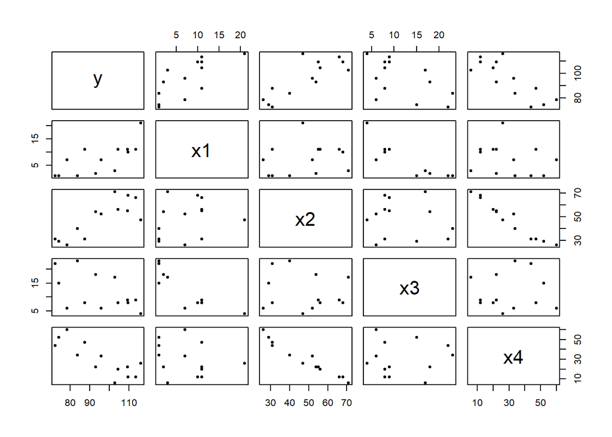

```r
pairs(hald,pch=20)
```

For this data set, if you want to build a model to predict `y`, which variables do you want to include in the regression?

```r
summary(lm(y~x1,data=hald))
```

```
##
## Call:
## lm(formula = y ~ x1, data = hald)
##
## Residuals:
##     Min      1Q  Median      3Q     Max
## -16.061  -9.048   1.339   7.883  15.614
##
## Coefficients:
##             Estimate Std. Error t value Pr(>|t|)
## (Intercept)  81.4793     4.9273   16.54 4.07e-09 ***
## x1            1.8687     0.5264    3.55  0.00455 **
## ---
## Signif. codes:  0 '***' 0.001 '**' 0.01 '*' 0.05 '.' 0.1 ' ' 1
##
## Residual standard error: 10.73 on 11 degrees of freedom
## Multiple R-squared:  0.5339, Adjusted R-squared:  0.4916
## F-statistic:  12.6 on 1 and 11 DF,  p-value: 0.004552
```

```r
summary(lm(y~x2,data=hald))
```

```
##
## Call:
## lm(formula = y ~ x2, data = hald)
##
## Residuals:
##     Min      1Q  Median      3Q     Max
## -10.752  -6.008  -1.684   3.794  21.387
##
## Coefficients:
##             Estimate Std. Error t value Pr(>|t|)
## (Intercept)  57.4237     8.4906   6.763  3.1e-05 ***
## x2            0.7891     0.1684   4.686 0.000665 ***
## ---
## Signif. codes:  0 '***' 0.001 '**' 0.01 '*' 0.05 '.' 0.1 ' ' 1
##
## Residual standard error: 9.077 on 11 degrees of freedom
## Multiple R-squared:  0.6663, Adjusted R-squared:  0.6359
## F-statistic: 21.96 on 1 and 11 DF,  p-value: 0.0006648
```

```r
summary(lm(y~x3,data=hald))
```

```
##
## Call:
## lm(formula = y ~ x3, data = hald)
##
## Residuals:
##     Min      1Q  Median      3Q     Max
## -24.168 -10.075   4.144  10.299  14.399
##
## Coefficients:
##             Estimate Std. Error t value Pr(>|t|)
## (Intercept) 110.2027     7.9478  13.866  2.6e-08 ***
## x3           -1.2558     0.5984  -2.098   0.0598 .
## ---
## Signif. codes:  0 '***' 0.001 '**' 0.01 '*' 0.05 '.' 0.1 ' ' 1
##
## Residual standard error: 13.28 on 11 degrees of freedom
## Multiple R-squared:  0.2859, Adjusted R-squared:  0.221
## F-statistic: 4.403 on 1 and 11 DF,  p-value: 0.05976
```

```r
summary(lm(y~x4,data=hald))
```

```
##
## Call:
## lm(formula = y ~ x4, data = hald)
##
## Residuals:
##     Min      1Q  Median      3Q     Max
## -12.589  -8.228   1.495   4.726  17.524
##
## Coefficients:
##             Estimate Std. Error t value Pr(>|t|)
## (Intercept) 117.5679     5.2622  22.342 1.62e-10 ***
## x4           -0.7382     0.1546  -4.775 0.000576 ***
## ---
## Signif. codes:  0 '***' 0.001 '**' 0.01 '*' 0.05 '.' 0.1 ' ' 1
##
## Residual standard error: 8.964 on 11 degrees of freedom
## Multiple R-squared:  0.6745, Adjusted R-squared:  0.645
## F-statistic:  22.8 on 1 and 11 DF,  p-value: 0.0005762
```

```r
summary(lm(y~x1+x2+x3+x4,data=hald))
```

```
##
## Call:
## lm(formula = y ~ x1 + x2 + x3 + x4, data = hald)
##
## Residuals:
##     Min      1Q  Median      3Q     Max
## -3.1750 -1.6709  0.2508  1.3783  3.9254
##
## Coefficients:
##             Estimate Std. Error t value Pr(>|t|)
## (Intercept)  62.4054    70.0710   0.891   0.3991
## x1            1.5511     0.7448   2.083   0.0708 .
## x2            0.5102     0.7238   0.705   0.5009
## x3            0.1019     0.7547   0.135   0.8959
## x4           -0.1441     0.7091  -0.203   0.8441
## ---
## Signif. codes:  0 '***' 0.001 '**' 0.01 '*' 0.05 '.' 0.1 ' ' 1
##
## Residual standard error: 2.446 on 8 degrees of freedom
## Multiple R-squared:  0.9824, Adjusted R-squared:  0.9736
## F-statistic: 111.5 on 4 and 8 DF,  p-value: 4.756e-07
```

Obviously, models with only one covariate is too weak for prediction, but the model with all covariates included have all insignificant p-values. So what is the best model?

Model-Building Problem

- “Conflicting” goals in regression model building:
- Want as many regressors as possible so that the “information content” in the variables will influence the fitted values
- Want as few regressors as necessary because the variance of parameter estimates and fitted values will increase as the number of regressors increases and more regressors can cost more money in data collection/model maintenance
- Need to find a compromise that leads to the best regression equation

Notes on Variable selection techniques.

- None of the variable selection techniques can guarantee the best regression equation for the dataset of interest
- The techniques may very well give different results
- Complete reliance on the algorithm for results is to be avoided
- Other valuable information such as experience with and knowledge of the data and problem should be utilized

Consequences of Deleting Variables

- Improves the precision of the parameter estimates of retained variables
- Improves the precision of the variance of the predicted response
- Can induce bias into the estimates of coefficients and variance of predicted response

What if transformation is needed for some of the covariates? Here is the strategy for regression model building.

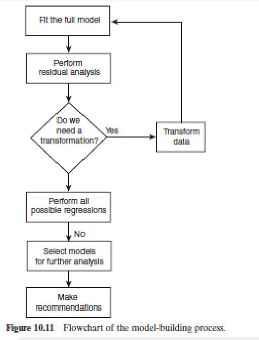

All Possible Regressions

- Assume the intercept term is in all equations
- If there are $k$ regressors, we would investigate $2^k$ possible regression equations
- Use the criteria discussed to determine some candidate models
- Complete regression analysis on candidate models

Criterion for variable selection

- Adjusted R squared (or Prediction R squared or PRESS)
- AIC or BIC
- Stepwise regression

# 2 Select by Adjusted R squared

The coefficient of determination $R^2$ is defined as

$$R^2= 1 - \frac{SSRes}{SST}$$

- Large values of $R^2$ are preferred, however, adding covariates will only increase this value.
- Not a good measurement for variable selection.

For a model with k covariates, the adjusted R squared is

$$R^2_{adj}= 1- \frac{n-1}{n-k-1}\bigg(\frac{SSRes}{SST}\bigg)=1 - \frac{n-1}{n-k-1}(1-R^2)$$

- This value will not necessarily increase as additional terms are introduced into the model
- Large values of adjusted R2 are preferred
- Adjusted R squared is a good measurement for variable selection.

**Example**

```r
library(leaps)
hald_allmodels_r2 <- leaps( x=hald[,-1], y=hald[,1], method="r2")
hald_allmodels_r2
```

```
## $which
##       1     2     3     4
## 1 FALSE FALSE FALSE  TRUE
## 1 FALSE  TRUE FALSE FALSE
## 1  TRUE FALSE FALSE FALSE
## 1 FALSE FALSE  TRUE FALSE
## 2  TRUE  TRUE FALSE FALSE
## 2  TRUE FALSE FALSE  TRUE
## 2 FALSE FALSE  TRUE  TRUE
## 2 FALSE  TRUE  TRUE FALSE
## 2 FALSE  TRUE FALSE  TRUE
## 2  TRUE FALSE  TRUE FALSE
## 3  TRUE  TRUE FALSE  TRUE
## 3  TRUE  TRUE  TRUE FALSE
## 3  TRUE FALSE  TRUE  TRUE
## 3 FALSE  TRUE  TRUE  TRUE
## 4  TRUE  TRUE  TRUE  TRUE
##
## $label
## [1] "(Intercept)" "1"           "2"           "3"           "4"
##
## $size
##  [1] 2 2 2 2 3 3 3 3 3 3 4 4 4 4 5
##
## $r2
##  [1] 0.6745420 0.6662683 0.5339480 0.2858727 0.9786784 0.9724710 0.9352896
##  [8] 0.8470254 0.6800604 0.5481667 0.9823355 0.9822847 0.9812811 0.9728200
## [15] 0.9823756
```

```r
cbind(hald_allmodels_r2$which, Rsq = hald_allmodels_r2$r2)
```

```
##   1 2 3 4       Rsq
## 1 0 0 0 1 0.6745420
## 1 0 1 0 0 0.6662683
## 1 1 0 0 0 0.5339480
## 1 0 0 1 0 0.2858727
## 2 1 1 0 0 0.9786784
## 2 1 0 0 1 0.9724710
## 2 0 0 1 1 0.9352896
## 2 0 1 1 0 0.8470254
## 2 0 1 0 1 0.6800604
## 2 1 0 1 0 0.5481667
## 3 1 1 0 1 0.9823355
## 3 1 1 1 0 0.9822847
## 3 1 0 1 1 0.9812811
## 3 0 1 1 1 0.9728200
## 4 1 1 1 1 0.9823756
```

```r
hald_allmodels_r2adj <- leaps( x=hald[,-1], y=hald[,1], method="adjr2")
hald_allmodels_r2adj
```

```
## $which
##       1     2     3     4
## 1 FALSE FALSE FALSE  TRUE
## 1 FALSE  TRUE FALSE FALSE
## 1  TRUE FALSE FALSE FALSE
## 1 FALSE FALSE  TRUE FALSE
## 2  TRUE  TRUE FALSE FALSE
## 2  TRUE FALSE FALSE  TRUE
## 2 FALSE FALSE  TRUE  TRUE
## 2 FALSE  TRUE  TRUE FALSE
## 2 FALSE  TRUE FALSE  TRUE
## 2  TRUE FALSE  TRUE FALSE
## 3  TRUE  TRUE FALSE  TRUE
## 3  TRUE  TRUE  TRUE FALSE
## 3  TRUE FALSE  TRUE  TRUE
## 3 FALSE  TRUE  TRUE  TRUE
## 4  TRUE  TRUE  TRUE  TRUE
##
## $label
## [1] "(Intercept)" "1"           "2"           "3"           "4"
##
## $size
##  [1] 2 2 2 2 3 3 3 3 3 3 4 4 4 4 5
##
## $adjr2
##  [1] 0.6449549 0.6359290 0.4915797 0.2209521 0.9744140 0.9669653 0.9223476
##  [8] 0.8164305 0.6160725 0.4578001 0.9764473 0.9763796 0.9750415 0.9637599
## [15] 0.9735634
```

```r
cbind(hald_allmodels_r2adj$which, adjRsq = hald_allmodels_r2adj$adjr2)
```

```
##   1 2 3 4    adjRsq
## 1 0 0 0 1 0.6449549
## 1 0 1 0 0 0.6359290
## 1 1 0 0 0 0.4915797
## 1 0 0 1 0 0.2209521
## 2 1 1 0 0 0.9744140
## 2 1 0 0 1 0.9669653
## 2 0 0 1 1 0.9223476
## 2 0 1 1 0 0.8164305
## 2 0 1 0 1 0.6160725
## 2 1 0 1 0 0.4578001
## 3 1 1 0 1 0.9764473
## 3 1 1 1 0 0.9763796
## 3 1 0 1 1 0.9750415
## 3 0 1 1 1 0.9637599
## 4 1 1 1 1 0.9735634
```

According adjusted R squared, `## 3 1 1 0 1 0.9764473` corresponds to the best model. That is, `x1`, `x2`, and `x4` should be included in the regression.

Another example:

```r
asphalt <- read.csv("data_Asphalt.csv",header=TRUE)
head(asphalt)
```

```
##   Observation     y  x1   x2   x3 x4  x5    x6
## 1           1  6.75 2.8 4.68 4.87  0 8.4 4.916
## 2           2 13.00 1.4 5.19 4.50  0 6.5 4.563
## 3           3 14.75 1.4 4.82 4.73  0 7.9 5.321
## 4           4 12.60 3.3 4.85 4.76  0 8.3 4.865
## 5           5  8.25 1.7 4.86 4.95  0 8.4 3.776
## 6           6 10.67 2.9 5.16 4.45  0 7.4 4.397
```

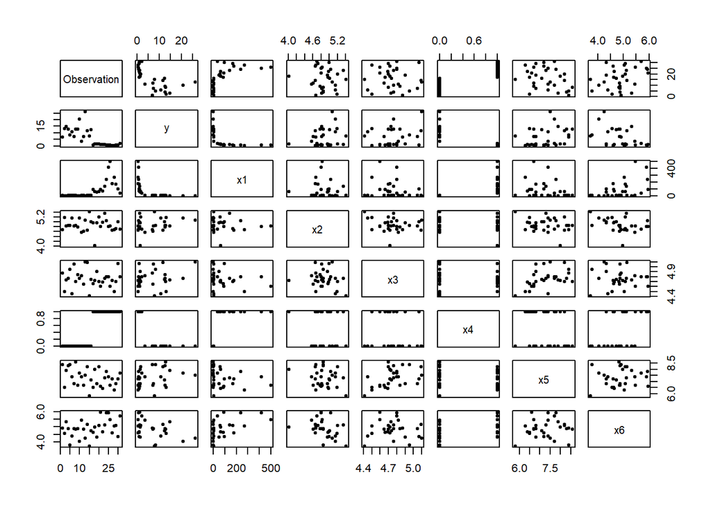

```r
pairs(asphalt,pch=20)
```

```r
asphalt_allmodels_r2 <- leaps(x=asphalt[,3:8],y=asphalt[,2], method="r2")
asphalt_allmodels_r2
```

```
## $which
##       1     2     3     4     5     6
## 1 FALSE FALSE FALSE  TRUE FALSE FALSE
## 1  TRUE FALSE FALSE FALSE FALSE FALSE
## 1 FALSE FALSE FALSE FALSE FALSE  TRUE
## 1 FALSE FALSE FALSE FALSE  TRUE FALSE
## 1 FALSE  TRUE FALSE FALSE FALSE FALSE
## 1 FALSE FALSE  TRUE FALSE FALSE FALSE
## 2 FALSE  TRUE FALSE  TRUE FALSE FALSE
## 2 FALSE FALSE  TRUE  TRUE FALSE FALSE
## 2 FALSE FALSE FALSE  TRUE FALSE  TRUE
## 2 FALSE FALSE FALSE  TRUE  TRUE FALSE
## 2  TRUE FALSE FALSE  TRUE FALSE FALSE
## 2  TRUE  TRUE FALSE FALSE FALSE FALSE
## 2  TRUE FALSE FALSE FALSE FALSE  TRUE
```

[output cut: 48 more lines]

```r
cbind(asphalt_allmodels_r2$which,Rsq=asphalt_allmodels_r2$r2)
```

```
##   1 2 3 4 5 6        Rsq
## 1 0 0 0 1 0 0 0.65755827
## 1 1 0 0 0 0 0 0.31095511
## 1 0 0 0 0 0 1 0.17970996
## 1 0 0 0 0 1 0 0.07244760
## 1 0 1 0 0 0 0 0.05871311
## 1 0 0 1 0 0 0 0.04418471
## 2 0 1 0 1 0 0 0.67988500
## 2 0 0 1 1 0 0 0.67054203
## 2 0 0 0 1 0 1 0.66837794
## 2 0 0 0 1 1 0 0.66422324
## 2 1 0 0 1 0 0 0.65895778
## 2 1 1 0 0 0 0 0.34851619
## 2 1 0 0 0 0 1 0.34222182
## 2 1 0 0 0 1 0 0.33205132
```

[output cut: 29 more lines]

```r
asphalt_allmodels_r2adj <- leaps(x=asphalt[,3:8],y=asphalt[,2], method="adjr2")
asphalt_allmodels_r2adj
```

```
## $which
##       1     2     3     4     5     6
## 1 FALSE FALSE FALSE  TRUE FALSE FALSE
## 1  TRUE FALSE FALSE FALSE FALSE FALSE
## 1 FALSE FALSE FALSE FALSE FALSE  TRUE
## 1 FALSE FALSE FALSE FALSE  TRUE FALSE
## 1 FALSE  TRUE FALSE FALSE FALSE FALSE
## 1 FALSE FALSE  TRUE FALSE FALSE FALSE
## 2 FALSE  TRUE FALSE  TRUE FALSE FALSE
## 2 FALSE FALSE  TRUE  TRUE FALSE FALSE
## 2 FALSE FALSE FALSE  TRUE FALSE  TRUE
## 2 FALSE FALSE FALSE  TRUE  TRUE FALSE
## 2  TRUE FALSE FALSE  TRUE FALSE FALSE
## 2  TRUE  TRUE FALSE FALSE FALSE FALSE
## 2  TRUE FALSE FALSE FALSE FALSE  TRUE
```

[output cut: 48 more lines]

```r
cbind(asphalt_allmodels_r2adj$which,adjRsq=asphalt_allmodels_r2adj$adjr2)
```

```
##   1 2 3 4 5 6     adjRsq
## 1 0 0 0 1 0 0 0.64574994
## 1 1 0 0 0 0 0 0.28719494
## 1 0 0 0 0 0 1 0.15142410
## 1 0 0 0 0 1 0 0.04046303
## 1 0 1 0 0 0 0 0.02625494
## 1 0 0 1 0 0 0 0.01122557
## 2 0 1 0 1 0 0 0.65701964
## 2 0 0 1 1 0 0 0.64700932
## 2 0 0 0 1 0 1 0.64469065
## 2 0 0 0 1 1 0 0.64023918
## 2 1 0 0 1 0 0 0.63459762
## 2 1 1 0 0 0 0 0.30198163
## 2 1 0 0 0 0 1 0.29523766
## 2 1 0 0 0 1 0 0.28434070
```

[output cut: 29 more lines]

A third example:

```r
n=1000
x1=rnorm(n)
x2=rnorm(n)
x3=rnorm(n)
x4=rnorm(n)
y=1+2*x1+3*x2+rnorm(n)
results=leaps( x=cbind(x1,x2,x3,x4), y=y, method="r2")
cbind(results$which, Rsq=results$r2)
```

```
##   1 2 3 4          Rsq
## 1 0 1 0 0 0.6097956074
## 1 1 0 0 0 0.2954778659
## 1 0 0 0 1 0.0012368128
## 1 0 0 1 0 0.0003920018
## 2 1 1 0 0 0.9261756045
## 2 0 1 1 0 0.6103199511
## 2 0 1 0 1 0.6098169039
## 2 1 0 0 1 0.2962985076
## 2 1 0 1 0 0.2955210672
## 2 0 0 1 1 0.0016020574
## 3 1 1 1 0 0.9261944546
## 3 1 1 0 1 0.9261827416
## 3 0 1 1 1 0.6103372699
## 3 1 0 1 1 0.2963492196
## 4 1 1 1 1 0.9262011552
```

```r
results2=leaps( x=cbind(x1,x2,x3,x4), y=y, method="adjr2")
cbind(results2$which, adjRsq=results2$adjr2)
```

```
##   1 2 3 4        adjRsq
## 1 0 1 0 0  0.6094046210
## 1 1 0 0 0  0.2947719319
## 1 0 0 0 1  0.0002360481
## 1 0 0 1 0 -0.0006096094
## 2 1 1 0 0  0.9260275114
## 2 0 1 1 0  0.6095382459
## 2 0 1 0 1  0.6090341895
## 2 1 0 0 1  0.2948868697
## 2 1 0 1 0  0.2941078697
## 2 0 0 1 1 -0.0004007469
## 3 1 1 1 0  0.9259721487
## 3 1 1 0 1  0.9259604005
## 3 0 1 1 1  0.6091635869
## 3 1 0 1 1  0.2942297895
## 4 1 1 1 1  0.9259044764
```

# 3 select by AIC and BIC

AIC: Akaike’s Information Criterion

$$AIC = n \log\bigg(\frac{SSRes}{n}\bigg) + 2p$$

BIC: Bayesian Information Criterion

$$BIC = n \log\bigg(\frac{SSRes}{n}\bigg) + p \log(n)$$

- $p$ is the number of parameters in the model. In linear regression, $p=k+1$, i.e., intercept plus slopes.
- The models with small values of AIC or BIC are preferred.
- Commonly used for more complicated modeling situations

**Example**

```r
hald_allmodels=regsubsets(y~x1+x2+x3+x4, data=hald, nbest=4)
summary(hald_allmodels)
```

```
## Subset selection object
## Call: regsubsets.formula(y ~ x1 + x2 + x3 + x4, data = hald, nbest = 4)
## 4 Variables  (and intercept)
##    Forced in Forced out
## x1     FALSE      FALSE
## x2     FALSE      FALSE
## x3     FALSE      FALSE
## x4     FALSE      FALSE
## 4 subsets of each size up to 4
## Selection Algorithm: exhaustive
##          x1  x2  x3  x4
## 1  ( 1 ) " " " " " " "*"
## 1  ( 2 ) " " "*" " " " "
## 1  ( 3 ) "*" " " " " " "
## 1  ( 4 ) " " " " "*" " "
## 2  ( 1 ) "*" "*" " " " "
## 2  ( 2 ) "*" " " " " "*"
## 2  ( 3 ) " " " " "*" "*"
## 2  ( 4 ) " " "*" "*" " "
## 3  ( 1 ) "*" "*" " " "*"
## 3  ( 2 ) "*" "*" "*" " "
## 3  ( 3 ) "*" " " "*" "*"
## 3  ( 4 ) " " "*" "*" "*"
## 4  ( 1 ) "*" "*" "*" "*"
```

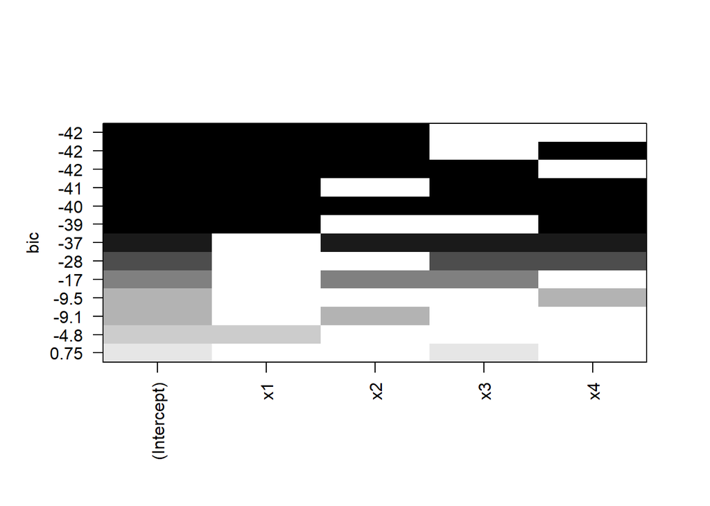

```r
plot(hald_allmodels, scale="bic")
```

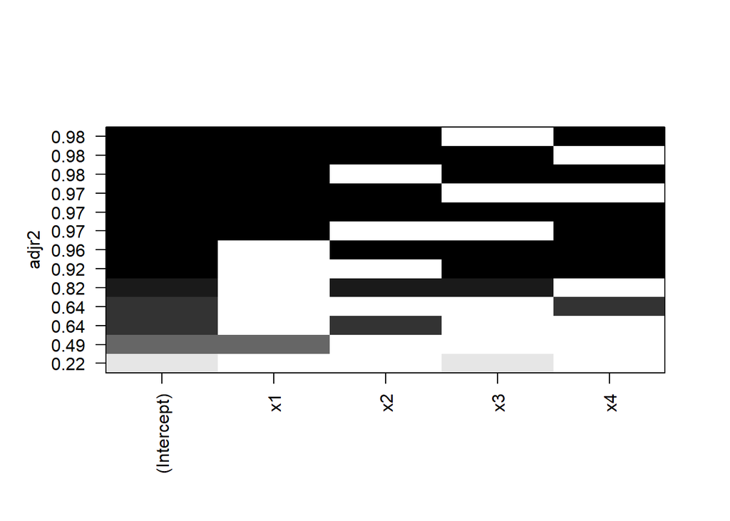

```r
plot(hald_allmodels, scale="adjr2")
```

Another example

```r
asphalt_allmodels <- regsubsets(y~x1+x2+x3+x4+x5+x6,data=asphalt,nbest=3)
summary(asphalt_allmodels)
```

```
## Subset selection object
## Call: regsubsets.formula(y ~ x1 + x2 + x3 + x4 + x5 + x6, data = asphalt,
##     nbest = 3)
## 6 Variables  (and intercept)
##    Forced in Forced out
## x1     FALSE      FALSE
## x2     FALSE      FALSE
## x3     FALSE      FALSE
## x4     FALSE      FALSE
## x5     FALSE      FALSE
## x6     FALSE      FALSE
## 3 subsets of each size up to 6
## Selection Algorithm: exhaustive
##          x1  x2  x3  x4  x5  x6
## 1  ( 1 ) " " " " " " "*" " " " "
## 1  ( 2 ) "*" " " " " " " " " " "
## 1  ( 3 ) " " " " " " " " " " "*"
## 2  ( 1 ) " " "*" " " "*" " " " "
## 2  ( 2 ) " " " " "*" "*" " " " "
## 2  ( 3 ) " " " " " " "*" " " "*"
## 3  ( 1 ) " " "*" "*" "*" " " " "
## 3  ( 2 ) " " "*" " " "*" "*" " "
## 3  ( 3 ) " " "*" " " "*" " " "*"
## 4  ( 1 ) " " "*" "*" "*" "*" " "
## 4  ( 2 ) " " "*" "*" "*" " " "*"
## 4  ( 3 ) "*" "*" "*" "*" " " " "
## 5  ( 1 ) " " "*" "*" "*" "*" "*"
## 5  ( 2 ) "*" "*" "*" "*" "*" " "
## 5  ( 3 ) "*" "*" "*" "*" " " "*"
## 6  ( 1 ) "*" "*" "*" "*" "*" "*"
```

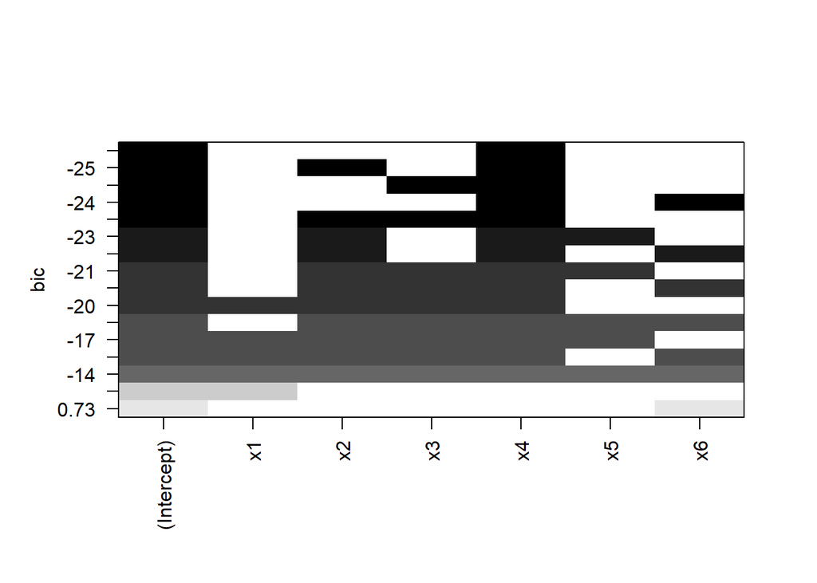

```r
plot(asphalt_allmodels)
```

A third example

```r
n=1000
x1=rnorm(n)
x2=rnorm(n)
x3=rnorm(n)
x4=rnorm(n)
y=1+2*x1+3*x2+rnorm(n)
m1=lm(y~x1)
m2=lm(y~x1+x2)
m3=lm(y~x1+x2+x3)
m4=lm(y~x1+x2+x3+x4)
BIC(m1)
```

```
## [1] 5190.934
```

```r
BIC(m2)
```

```
## [1] 2842.267
```

```r
BIC(m3)
```

```
## [1] 2847.547
```

```r
BIC(m4)
```

```
## [1] 2854.439
```

```r
AIC(m1)
```

```
## [1] 5176.211
```

```r
AIC(m2)
```

```
## [1] 2822.636
```

```r
AIC(m3)
```

```
## [1] 2823.008
```

```r
AIC(m4)
```

```
## [1] 2824.992
```

# 4 Stepwise regression

Stepwise regression methods include:

- Forward Selection
- Backward Elimination
- Stepwise Regression (combination of forward and backward)

Forward Selection

- Procedure is based on the idea that no variables are in the model originally, but are added one at a time
- The first regressor selected to be entered into the model is the one with the highest correlation with the response
- If the F test corresponding to the model containing this variable is significant (larger than some predetermined value), then that regressor is left in the model
- The second regressor examined is the one with the largest partial correlation with the response. If the F-statistic corresponding to the addition of this variable is significant, the regressor is retained
- This process continues until all regressors are examined

**Example** Hald data set

```r
# forward selection using F
add1(lm(y~1,data=hald), y~x1+x2+x3+x4, test="F")
```

```
## Single term additions
##
## Model:
## y ~ 1
##        Df Sum of Sq     RSS    AIC F value    Pr(>F)
## <none>              2715.76 71.444
## x1      1   1450.08 1265.69 63.519 12.6025 0.0045520 **
## x2      1   1809.43  906.34 59.178 21.9606 0.0006648 ***
## x3      1    776.36 1939.40 69.067  4.4034 0.0597623 .
## x4      1   1831.90  883.87 58.852 22.7985 0.0005762 ***
## ---
## Signif. codes:  0 '***' 0.001 '**' 0.01 '*' 0.05 '.' 0.1 ' ' 1
```

```r
add1(lm(y~x4,data=hald), y~x1+x2+x3+x4, test="F")
```

```
## Single term additions
##
## Model:
## y ~ x4
##        Df Sum of Sq    RSS    AIC  F value    Pr(>F)
## <none>              883.87 58.852
## x1      1    809.10  74.76 28.742 108.2239 1.105e-06 ***
## x2      1     14.99 868.88 60.629   0.1725    0.6867
## x3      1    708.13 175.74 39.853  40.2946 8.375e-05 ***
## ---
## Signif. codes:  0 '***' 0.001 '**' 0.01 '*' 0.05 '.' 0.1 ' ' 1
```

```r
add1(lm(y~x1+x4,data=hald), y~x1+x2+x3+x4, test="F")
```

```
## Single term additions
##
## Model:
## y ~ x1 + x4
##        Df Sum of Sq    RSS    AIC F value  Pr(>F)
## <none>              74.762 28.742
## x2      1    26.789 47.973 24.974  5.0259 0.05169 .
## x3      1    23.926 50.836 25.728  4.2358 0.06969 .
## ---
## Signif. codes:  0 '***' 0.001 '**' 0.01 '*' 0.05 '.' 0.1 ' ' 1
```

**End of Example**

Backward Elimination

- Procedure is based on the idea that all variables are in the model originally and examined one at a time and removed if not significant
- The partial F statistic is calculated for each variable as if it were the last one added to the model
- The regressor with the smallest F statistic is examined first and will be removed if this value is less than some predetermined value Fout
- If this regressor is removed, then the model is refit with the remaining regressor variables and the partial F statistics calculated again
- The regressor with the smallest partial F statistic will be removed if that value is less than Fout.
- The process continues until all regressors are examined

**Example** Hald data set

```r
# backward selection using F
drop1(lm(y~x1+x2+x3+x4,data=hald), test="F")
```

```
## Single term deletions
##
## Model:
## y ~ x1 + x2 + x3 + x4
##        Df Sum of Sq    RSS    AIC F value  Pr(>F)
## <none>              47.864 26.944
## x1      1   25.9509 73.815 30.576  4.3375 0.07082 .
## x2      1    2.9725 50.836 25.728  0.4968 0.50090
## x3      1    0.1091 47.973 24.974  0.0182 0.89592
## x4      1    0.2470 48.111 25.011  0.0413 0.84407
## ---
## Signif. codes:  0 '***' 0.001 '**' 0.01 '*' 0.05 '.' 0.1 ' ' 1
```

```r
drop1(lm(y~x1+x2+x4,data=hald), test="F")
```

```
## Single term deletions
##
## Model:
## y ~ x1 + x2 + x4
##        Df Sum of Sq    RSS    AIC  F value    Pr(>F)
## <none>               47.97 24.974
## x1      1    820.91 868.88 60.629 154.0076 5.781e-07 ***
## x2      1     26.79  74.76 28.742   5.0259   0.05169 .
## x4      1      9.93  57.90 25.420   1.8633   0.20540
## ---
## Signif. codes:  0 '***' 0.001 '**' 0.01 '*' 0.05 '.' 0.1 ' ' 1
```

```r
drop1(lm(y~x1+x2,data=hald), test="F")
```

```
## Single term deletions
##
## Model:
## y ~ x1 + x2
##        Df Sum of Sq     RSS    AIC F value    Pr(>F)
## <none>                57.90 25.420
## x1      1    848.43  906.34 59.178  146.52 2.692e-07 ***
## x2      1   1207.78 1265.69 63.519  208.58 5.029e-08 ***
## ---
## Signif. codes:  0 '***' 0.001 '**' 0.01 '*' 0.05 '.' 0.1 ' ' 1
```

**End of Example**

Stepwise Regression

- This procedure is a modification of forward selection
- The contribution of each regressor variable that is put into the model is reassessed by way of its partial F statistic
- A regressor that makes it into the model, may also be removed it if is found to be insignificant with the addition of other variables to the model
- If the partial F-statistic is less than Fout, the variable will be removed.
- Stepwise requires both an Fin value and Fout value

Stepwise Regression Methods

- No one model may be the “best”
- The three stepwise techniques could result in different models
- Inexperienced analysts may use the final model simply because the procedure spit it out.

**Example** Hald data set

```r
# stepwise selection using F
add1(lm(y~1,data=hald), y~x1+x2+x3+x4, test="F")
```

```
## Single term additions
##
## Model:
## y ~ 1
##        Df Sum of Sq     RSS    AIC F value    Pr(>F)
## <none>              2715.76 71.444
## x1      1   1450.08 1265.69 63.519 12.6025 0.0045520 **
## x2      1   1809.43  906.34 59.178 21.9606 0.0006648 ***
## x3      1    776.36 1939.40 69.067  4.4034 0.0597623 .
## x4      1   1831.90  883.87 58.852 22.7985 0.0005762 ***
## ---
## Signif. codes:  0 '***' 0.001 '**' 0.01 '*' 0.05 '.' 0.1 ' ' 1
```

```r
add1(lm(y~x4,data=hald), y~x1+x2+x3+x4, test="F")
```

```
## Single term additions
##
## Model:
## y ~ x4
##        Df Sum of Sq    RSS    AIC  F value    Pr(>F)
## <none>              883.87 58.852
## x1      1    809.10  74.76 28.742 108.2239 1.105e-06 ***
## x2      1     14.99 868.88 60.629   0.1725    0.6867
## x3      1    708.13 175.74 39.853  40.2946 8.375e-05 ***
## ---
## Signif. codes:  0 '***' 0.001 '**' 0.01 '*' 0.05 '.' 0.1 ' ' 1
```

```r
add1(lm(y~x1+x4,data=hald), y~x1+x2+x3+x4, test="F")
```

```
## Single term additions
##
## Model:
## y ~ x1 + x4
##        Df Sum of Sq    RSS    AIC F value  Pr(>F)
## <none>              74.762 28.742
## x2      1    26.789 47.973 24.974  5.0259 0.05169 .
## x3      1    23.926 50.836 25.728  4.2358 0.06969 .
## ---
## Signif. codes:  0 '***' 0.001 '**' 0.01 '*' 0.05 '.' 0.1 ' ' 1
```

```r
add1(lm(y~x1+x2+x4,data=hald), y~x1+x2+x3+x4, test="F")
```

```
## Single term additions
##
## Model:
## y ~ x1 + x2 + x4
##        Df Sum of Sq    RSS    AIC F value Pr(>F)
## <none>              47.973 24.974
## x3      1   0.10909 47.864 26.944  0.0182 0.8959
```

```r
drop1(lm(y~x1+x2+x4,data=hald), test="F")
```

```
## Single term deletions
##
## Model:
## y ~ x1 + x2 + x4
##        Df Sum of Sq    RSS    AIC  F value    Pr(>F)
## <none>               47.97 24.974
## x1      1    820.91 868.88 60.629 154.0076 5.781e-07 ***
## x2      1     26.79  74.76 28.742   5.0259   0.05169 .
## x4      1      9.93  57.90 25.420   1.8633   0.20540
## ---
## Signif. codes:  0 '***' 0.001 '**' 0.01 '*' 0.05 '.' 0.1 ' ' 1
```

```r
drop1(lm(y~x1+x2,data=hald), test="F")
```

```
## Single term deletions
##
## Model:
## y ~ x1 + x2
##        Df Sum of Sq     RSS    AIC F value    Pr(>F)
## <none>                57.90 25.420
## x1      1    848.43  906.34 59.178  146.52 2.692e-07 ***
## x2      1   1207.78 1265.69 63.519  208.58 5.029e-08 ***
## ---
## Signif. codes:  0 '***' 0.001 '**' 0.01 '*' 0.05 '.' 0.1 ' ' 1
```

Similary, we could use AIC for stepwise regression.

```r
# stepwise selection using AIC
null=lm(y~1, data=hald)
full=lm(y~., data=hald)
step(null, scope=list(lower=null, upper=full), direction="forward")
```

```
## Start:  AIC=71.44
## y ~ 1
##
##        Df Sum of Sq     RSS    AIC
## + x4    1   1831.90  883.87 58.852
## + x2    1   1809.43  906.34 59.178
## + x1    1   1450.08 1265.69 63.519
## + x3    1    776.36 1939.40 69.067
## <none>              2715.76 71.444
##
## Step:  AIC=58.85
## y ~ x4
##
##        Df Sum of Sq    RSS    AIC
## + x1    1    809.10  74.76 28.742
## + x3    1    708.13 175.74 39.853
## <none>              883.87 58.852
## + x2    1     14.99 868.88 60.629
##
## Step:  AIC=28.74
## y ~ x4 + x1
##
##        Df Sum of Sq    RSS    AIC
## + x2    1    26.789 47.973 24.974
## + x3    1    23.926 50.836 25.728
## <none>              74.762 28.742
##
## Step:  AIC=24.97
## y ~ x4 + x1 + x2
##
##        Df Sum of Sq    RSS    AIC
## <none>              47.973 24.974
## + x3    1   0.10909 47.864 26.944
```

```
##
## Call:
## lm(formula = y ~ x4 + x1 + x2, data = hald)
##
## Coefficients:
## (Intercept)           x4           x1           x2
##     71.6483      -0.2365       1.4519       0.4161
```

```r
step(full, scope=list(lower=null, upper=full), direction="backward")
```

```
## Start:  AIC=26.94
## y ~ x1 + x2 + x3 + x4
##
##        Df Sum of Sq    RSS    AIC
## - x3    1    0.1091 47.973 24.974
## - x4    1    0.2470 48.111 25.011
## - x2    1    2.9725 50.836 25.728
## <none>              47.864 26.944
## - x1    1   25.9509 73.815 30.576
##
## Step:  AIC=24.97
## y ~ x1 + x2 + x4
##
##        Df Sum of Sq    RSS    AIC
## <none>               47.97 24.974
## - x4    1      9.93  57.90 25.420
## - x2    1     26.79  74.76 28.742
## - x1    1    820.91 868.88 60.629
```

```
##
## Call:
## lm(formula = y ~ x1 + x2 + x4, data = hald)
##
## Coefficients:
## (Intercept)           x1           x2           x4
##     71.6483       1.4519       0.4161      -0.2365
```

```r
step(full, scope=list(lower=null, upper=full), direction="both")
```

```
## Start:  AIC=26.94
## y ~ x1 + x2 + x3 + x4
##
##        Df Sum of Sq    RSS    AIC
## - x3    1    0.1091 47.973 24.974
## - x4    1    0.2470 48.111 25.011
## - x2    1    2.9725 50.836 25.728
## <none>              47.864 26.944
## - x1    1   25.9509 73.815 30.576
##
## Step:  AIC=24.97
## y ~ x1 + x2 + x4
##
##        Df Sum of Sq    RSS    AIC
## <none>               47.97 24.974
## - x4    1      9.93  57.90 25.420
## + x3    1      0.11  47.86 26.944
## - x2    1     26.79  74.76 28.742
## - x1    1    820.91 868.88 60.629
```

```
##
## Call:
## lm(formula = y ~ x1 + x2 + x4, data = hald)
##
## Coefficients:
## (Intercept)           x1           x2           x4
##     71.6483       1.4519       0.4161      -0.2365
```

```r
step(null, scope=list(lower=null, upper=full), direction="both")
```

```
## Start:  AIC=71.44
## y ~ 1
##
##        Df Sum of Sq     RSS    AIC
## + x4    1   1831.90  883.87 58.852
## + x2    1   1809.43  906.34 59.178
## + x1    1   1450.08 1265.69 63.519
## + x3    1    776.36 1939.40 69.067
## <none>              2715.76 71.444
##
## Step:  AIC=58.85
## y ~ x4
##
##        Df Sum of Sq     RSS    AIC
## + x1    1    809.10   74.76 28.742
## + x3    1    708.13  175.74 39.853
## <none>               883.87 58.852
## + x2    1     14.99  868.88 60.629
## - x4    1   1831.90 2715.76 71.444
##
## Step:  AIC=28.74
## y ~ x4 + x1
##
##        Df Sum of Sq     RSS    AIC
## + x2    1     26.79   47.97 24.974
## + x3    1     23.93   50.84 25.728
## <none>                74.76 28.742
## - x1    1    809.10  883.87 58.852
## - x4    1   1190.92 1265.69 63.519
##
## Step:  AIC=24.97
## y ~ x4 + x1 + x2
##
##        Df Sum of Sq    RSS    AIC
## <none>               47.97 24.974
## - x4    1      9.93  57.90 25.420
## + x3    1      0.11  47.86 26.944
## - x2    1     26.79  74.76 28.742
## - x1    1    820.91 868.88 60.629
```

```
##
## Call:
## lm(formula = y ~ x4 + x1 + x2, data = hald)
##
## Coefficients:
## (Intercept)           x4           x1           x2
##     71.6483      -0.2365       1.4519       0.4161
```

Similary, we could use BIC for stepwise regression.

```r
# stepwise selection using BIC
n=dim(hald)[1]
step(null, scope=list(lower=null, upper=full), k = log(n), direction="forward")
```

```
## Start:  AIC=72.01
## y ~ 1
##
##        Df Sum of Sq     RSS    AIC
## + x4    1   1831.90  883.87 59.982
## + x2    1   1809.43  906.34 60.308
## + x1    1   1450.08 1265.69 64.649
## + x3    1    776.36 1939.40 70.197
## <none>              2715.76 72.009
##
## Step:  AIC=59.98
## y ~ x4
##
##        Df Sum of Sq    RSS    AIC
## + x1    1    809.10  74.76 30.437
## + x3    1    708.13 175.74 41.547
## <none>              883.87 59.982
## + x2    1     14.99 868.88 62.324
##
## Step:  AIC=30.44
## y ~ x4 + x1
##
##        Df Sum of Sq    RSS    AIC
## + x2    1    26.789 47.973 27.234
## + x3    1    23.926 50.836 27.987
## <none>              74.762 30.437
##
## Step:  AIC=27.23
## y ~ x4 + x1 + x2
##
##        Df Sum of Sq    RSS    AIC
## <none>              47.973 27.234
## + x3    1   0.10909 47.864 29.769
```

```
##
## Call:
## lm(formula = y ~ x4 + x1 + x2, data = hald)
##
## Coefficients:
## (Intercept)           x4           x1           x2
##     71.6483      -0.2365       1.4519       0.4161
```

```r
step(full, scope=list(lower=null, upper=full), k = log(n), direction="backward")
```

```
## Start:  AIC=29.77
## y ~ x1 + x2 + x3 + x4
##
##        Df Sum of Sq    RSS    AIC
## - x3    1    0.1091 47.973 27.234
## - x4    1    0.2470 48.111 27.271
## - x2    1    2.9725 50.836 27.987
## <none>              47.864 29.769
## - x1    1   25.9509 73.815 32.836
##
## Step:  AIC=27.23
## y ~ x1 + x2 + x4
##
##        Df Sum of Sq    RSS    AIC
## - x4    1      9.93  57.90 27.115
## <none>               47.97 27.234
## - x2    1     26.79  74.76 30.437
## - x1    1    820.91 868.88 62.324
##
## Step:  AIC=27.11
## y ~ x1 + x2
##
##        Df Sum of Sq     RSS    AIC
## <none>                57.90 27.115
## - x1    1    848.43  906.34 60.308
## - x2    1   1207.78 1265.69 64.649
```

```
##
## Call:
## lm(formula = y ~ x1 + x2, data = hald)
##
## Coefficients:
## (Intercept)           x1           x2
##     52.5773       1.4683       0.6623
```

```r
step(full, scope=list(lower=null, upper=full), k = log(n), direction="both")
```

```
## Start:  AIC=29.77
## y ~ x1 + x2 + x3 + x4
##
##        Df Sum of Sq    RSS    AIC
## - x3    1    0.1091 47.973 27.234
## - x4    1    0.2470 48.111 27.271
## - x2    1    2.9725 50.836 27.987
## <none>              47.864 29.769
## - x1    1   25.9509 73.815 32.836
##
## Step:  AIC=27.23
## y ~ x1 + x2 + x4
##
##        Df Sum of Sq    RSS    AIC
## - x4    1      9.93  57.90 27.115
## <none>               47.97 27.234
## + x3    1      0.11  47.86 29.769
## - x2    1     26.79  74.76 30.437
## - x1    1    820.91 868.88 62.324
##
## Step:  AIC=27.11
## y ~ x1 + x2
##
##        Df Sum of Sq     RSS    AIC
## <none>                57.90 27.115
## + x4    1      9.93   47.97 27.234
## + x3    1      9.79   48.11 27.271
## - x1    1    848.43  906.34 60.308
## - x2    1   1207.78 1265.69 64.649
```

```
##
## Call:
## lm(formula = y ~ x1 + x2, data = hald)
##
## Coefficients:
## (Intercept)           x1           x2
##     52.5773       1.4683       0.6623
```

```r
step(null, scope=list(lower=null, upper=full), k = log(n), direction="both")
```

```
## Start:  AIC=72.01
## y ~ 1
##
##        Df Sum of Sq     RSS    AIC
## + x4    1   1831.90  883.87 59.982
## + x2    1   1809.43  906.34 60.308
## + x1    1   1450.08 1265.69 64.649
## + x3    1    776.36 1939.40 70.197
## <none>              2715.76 72.009
##
## Step:  AIC=59.98
## y ~ x4
##
##        Df Sum of Sq     RSS    AIC
## + x1    1    809.10   74.76 30.437
## + x3    1    708.13  175.74 41.547
## <none>               883.87 59.982
## + x2    1     14.99  868.88 62.324
## - x4    1   1831.90 2715.76 72.009
##
## Step:  AIC=30.44
## y ~ x4 + x1
##
##        Df Sum of Sq     RSS    AIC
## + x2    1     26.79   47.97 27.234
## + x3    1     23.93   50.84 27.987
## <none>                74.76 30.437
## - x1    1    809.10  883.87 59.982
## - x4    1   1190.92 1265.69 64.649
##
## Step:  AIC=27.23
## y ~ x4 + x1 + x2
##
##        Df Sum of Sq    RSS    AIC
## - x4    1      9.93  57.90 27.115
## <none>               47.97 27.234
## + x3    1      0.11  47.86 29.769
## - x2    1     26.79  74.76 30.437
## - x1    1    820.91 868.88 62.324
##
## Step:  AIC=27.11
## y ~ x1 + x2
##
##        Df Sum of Sq     RSS    AIC
## <none>                57.90 27.115
## + x4    1      9.93   47.97 27.234
## + x3    1      9.79   48.11 27.271
## - x1    1    848.43  906.34 60.308
## - x2    1   1207.78 1265.69 64.649
```

```
##
## Call:
## lm(formula = y ~ x1 + x2, data = hald)
##
## Coefficients:
## (Intercept)           x1           x2
##     52.5773       1.4683       0.6623
```

# 5 Lasso regression

LASSO stands for Least Absolute Shrinkage and Selection Operator. The algorithm is another variation of linear regression like ridge regression. We use lasso regression when we have large number of predictor variables.

Lasso regression selects variables and estimate coefficient simoutaneously, via apply L1 regularization.The L1 regularization adds a penality equivalent to the absolute of the maginitude of regression coefficients and tries to minimize them. The equation of lasso is similar to ridge regression and looks like as given below.

Traditional least square estimation:
$$\hat{\beta} = \arg\min \sum_{i=1}^{n} (y_i - \beta_0 - \sum_{j=1}^{k} \beta_j x_{ij})^2$$

Ridge Regression estimation:
$$\hat{\beta}_\lambda = \arg\min \sum_{i=1}^{n} (y_i - \beta_0 - \sum_{j=1}^{k} \beta_j x_{ij})^2 + \lambda \sum_{j=1}^{p} \beta_j^2$$

LASSO Regression estimation:
$$\hat{\beta}_\lambda = \arg\min \sum_{i=1}^{n} (y_i - \beta_0 - \sum_{j=1}^{k} \beta_j x_{ij})^2 + \lambda \sum_{j=1}^{p} |\beta_j |$$

The following diagram is the visual interpretation comparing OLS and lasso regression:

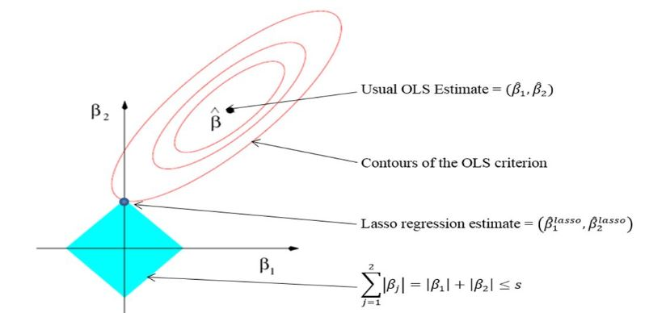

- think about $\beta = [5,5] and [10,0]$ in ridge regression and Lasso regression.
- If $\lambda$ = 0, We get same coefficients as linear regression If $\lambda$ = vary large, All coefficients are shriked towards zero. $\lambda$ controls the level of sparsity.
- The LASSO is not very good at handling variables which show correlation between them and thus can sometimes show very wild behaviors.

```r
library(glmnet)
```

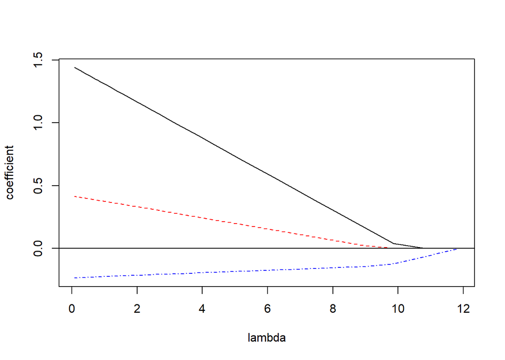

```r
lreg <- glmnet(x=as.matrix(hald[,-1]), y=hald[,1],alpha=1)
#rbind(lreg$lambda,lreg$beta)
matplot(lreg$lambda,t(lreg$beta),type="l",ylab="coefficient",xlab="lambda")
abline(h=0)
```

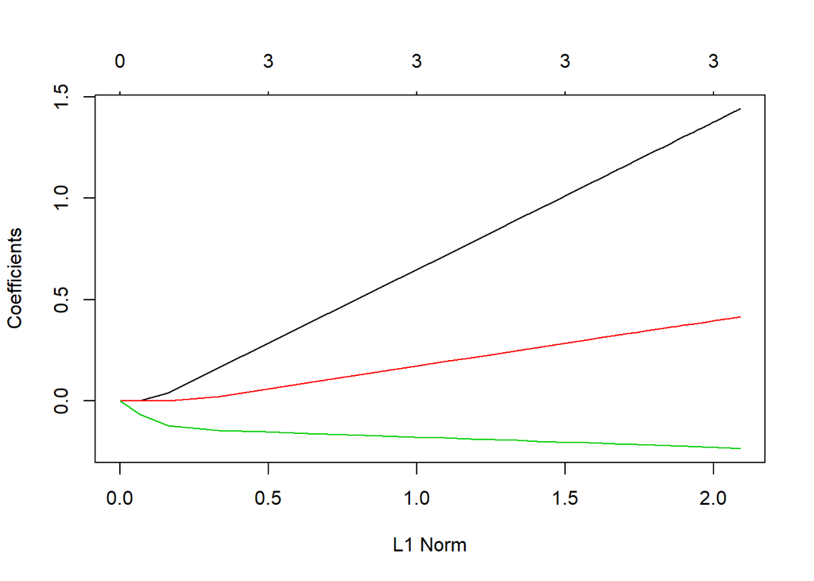

```r
plot(lreg)
```

We can apply cross-validation to find the best cv

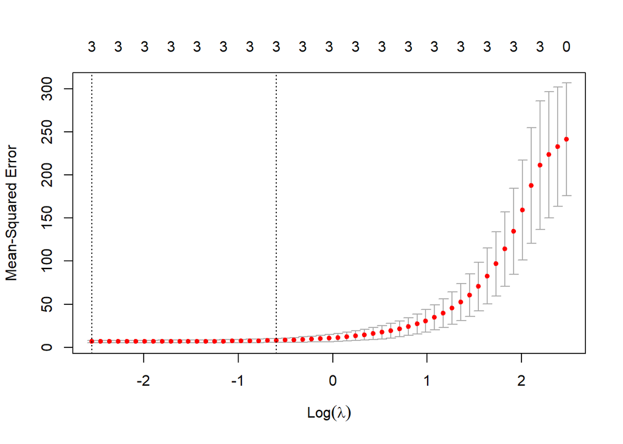

```r
cv_fit <- cv.glmnet(x=as.matrix(hald[,-1]), y=hald[,1],alpha=1,nfolds = 4)
plot(cv_fit)
```

```r
opt_lambda <- cv_fit$lambda.min
opt_lambda
```

```
## [1] 0.07810171
```

We can also predict with Lasso regression:

```r
#only matrix form is acceptable in ridge regression
old_x <- as.matrix(hald[,-1])
y_predicted <- predict(lreg, s = opt_lambda, newx = old_x)

newx <- matrix(c(x1=15,x2=50,x3=6,x4=70),ncol=4)
predict(lreg, s = opt_lambda, newx = newx)
```

```
##             1
## [1,] 97.64065
```

And the in-sample mse:

```r
mse <- mean((hald[,1] - y_predicted)^2)
mse
```

```
## [1] 3.700099
```

```r
#your turn, what's the in-sample mse from the best model selected by R-square?
```

### Another example Asphalt, try it!

```r
add1(lm(y~1,data=asphalt[,-1]), y~x1+x2+x3+x4+x5+x6, test="F")
```

```
## Single term additions
##
## Model:
## y ~ 1
##        Df Sum of Sq     RSS     AIC F value    Pr(>F)
## <none>              1366.52 119.367
## x1      1    424.93  941.59 109.821 13.0872  0.001117 **
## x2      1     80.23 1286.29 119.491  1.8089  0.189067
## x3      1     60.38 1306.14 119.966  1.3406  0.256377
## x4      1    898.57  467.95  88.146 55.6859 3.181e-08 ***
## x5      1     99.00 1267.52 119.036  2.2651  0.143134
## x6      1    245.58 1120.94 115.226  6.3533  0.017473 *
## ---
## Signif. codes:  0 '***' 0.001 '**' 0.01 '*' 0.05 '.' 0.1 ' ' 1
```

```r
add1(lm(y~x4,data=asphalt[,-1]), y~x1+x2+x3+x4+x5+x6, test="F")
```

```
## Single term additions
##
## Model:
## y ~ x4
##        Df Sum of Sq    RSS    AIC F value Pr(>F)
## <none>              467.95 88.146
## x1      1    1.9125 466.04 90.019  0.1149 0.7372
## x2      1   30.5099 437.44 88.056  1.9529 0.1733
## x3      1   17.7425 450.21 88.948  1.1035 0.3025
## x5      1    9.1078 458.85 89.536  0.5558 0.4622
## x6      1   14.7853 453.17 89.151  0.9135 0.3474
```

```r
drop1(lm(y~x4,data=asphalt[,-1]), test="F")
```

```
## Single term deletions
##
## Model:
## y ~ x4
##        Df Sum of Sq     RSS     AIC F value    Pr(>F)
## <none>               467.95  88.146
## x4      1    898.57 1366.52 119.367  55.686 3.181e-08 ***
## ---
## Signif. codes:  0 '***' 0.001 '**' 0.01 '*' 0.05 '.' 0.1 ' ' 1
```

```r
# stepwise with AIC
null=lm(y~1, data=asphalt[,-1])
full=lm(y~., data=asphalt[,-1])
step(null, scope=list(lower=null, upper=full), direction="forward")
```

```
## Start:  AIC=119.37
## y ~ 1
##
##        Df Sum of Sq     RSS     AIC
## + x4    1    898.57  467.95  88.146
## + x1    1    424.93  941.59 109.821
## + x6    1    245.58 1120.94 115.226
## + x5    1     99.00 1267.52 119.036
## <none>              1366.52 119.367
## + x2    1     80.23 1286.29 119.491
## + x3    1     60.38 1306.14 119.966
##
## Step:  AIC=88.15
## y ~ x4
##
##        Df Sum of Sq    RSS    AIC
## + x2    1   30.5099 437.44 88.056
## <none>              467.95 88.146
## + x3    1   17.7425 450.21 88.948
## + x6    1   14.7853 453.17 89.151
## + x5    1    9.1078 458.85 89.536
## + x1    1    1.9125 466.04 90.019
##
## Step:  AIC=88.06
## y ~ x4 + x2
##
##        Df Sum of Sq    RSS    AIC
## + x3    1   29.6911 407.75 87.877
## <none>              437.44 88.056
## + x5    1   21.6476 415.80 88.482
## + x6    1    4.0999 433.34 89.764
## + x1    1    1.6627 435.78 89.938
##
## Step:  AIC=87.88
## y ~ x4 + x2 + x3
##
##        Df Sum of Sq    RSS    AIC
## <none>              407.75 87.877
## + x5    1    7.4946 400.26 89.302
## + x6    1    3.0297 404.72 89.646
## + x1    1    0.1908 407.56 89.862
```

```
##
## Call:
## lm(formula = y ~ x4 + x2 + x3, data = asphalt[, -1])
##
## Coefficients:
## (Intercept)           x4           x2           x3
##     -38.229      -10.253        4.534        5.800
```

```r
step(full, scope=list(lower=null, upper=full), direction="backward")
```

```
## Start:  AIC=92.86
## y ~ x1 + x2 + x3 + x4 + x5 + x6
##
##        Df Sum of Sq    RSS     AIC
## - x1    1      0.30 394.87  90.882
## - x6    1      5.60 400.18  91.295
## - x5    1     10.13 404.70  91.644
## - x3    1     13.32 407.90  91.888
## <none>              394.57  92.858
## - x2    1     33.39 427.96  93.376
## - x4    1    401.66 796.24 112.623
##
## Step:  AIC=90.88
## y ~ x2 + x3 + x4 + x5 + x6
##
##        Df Sum of Sq    RSS     AIC
## - x6    1      5.38 400.26  89.302
## - x5    1      9.85 404.72  89.646
## - x3    1     13.08 407.95  89.892
## <none>              394.87  90.882
## - x2    1     33.87 428.74  91.433
## - x4    1    540.02 934.89 115.600
##
## Step:  AIC=89.3
## y ~ x2 + x3 + x4 + x5
##
##        Df Sum of Sq     RSS     AIC
## - x5    1      7.49  407.75  87.877
## - x3    1     15.54  415.80  88.482
## <none>               400.26  89.302
## - x2    1     48.10  448.36  90.820
## - x4    1    709.20 1109.46 118.907
##
## Step:  AIC=87.88
## y ~ x2 + x3 + x4
##
##        Df Sum of Sq     RSS     AIC
## <none>               407.75  87.877
## - x3    1     29.69  437.44  88.056
## - x2    1     42.46  450.21  88.948
## - x4    1    786.16 1193.92 119.181
```

```
##
## Call:
## lm(formula = y ~ x2 + x3 + x4, data = asphalt[, -1])
##
## Coefficients:
## (Intercept)           x2           x3           x4
##     -38.229        4.534        5.800      -10.253
```

```r
step(full, scope=list(lower=null, upper=full), direction="both")
```

```
## Start:  AIC=92.86
## y ~ x1 + x2 + x3 + x4 + x5 + x6
##
##        Df Sum of Sq    RSS     AIC
## - x1    1      0.30 394.87  90.882
## - x6    1      5.60 400.18  91.295
## - x5    1     10.13 404.70  91.644
## - x3    1     13.32 407.90  91.888
## <none>              394.57  92.858
## - x2    1     33.39 427.96  93.376
## - x4    1    401.66 796.24 112.623
##
## Step:  AIC=90.88
## y ~ x2 + x3 + x4 + x5 + x6
##
##        Df Sum of Sq    RSS     AIC
## - x6    1      5.38 400.26  89.302
## - x5    1      9.85 404.72  89.646
## - x3    1     13.08 407.95  89.892
## <none>              394.87  90.882
## - x2    1     33.87 428.74  91.433
## + x1    1      0.30 394.57  92.858
## - x4    1    540.02 934.89 115.600
##
## Step:  AIC=89.3
## y ~ x2 + x3 + x4 + x5
##
##        Df Sum of Sq     RSS     AIC
## - x5    1      7.49  407.75  87.877
## - x3    1     15.54  415.80  88.482
## <none>               400.26  89.302
## - x2    1     48.10  448.36  90.820
## + x6    1      5.38  394.87  90.882
## + x1    1      0.08  400.18  91.295
## - x4    1    709.20 1109.46 118.907
##
## Step:  AIC=87.88
## y ~ x2 + x3 + x4
##
##        Df Sum of Sq     RSS     AIC
## <none>               407.75  87.877
## - x3    1     29.69  437.44  88.056
## - x2    1     42.46  450.21  88.948
## + x5    1      7.49  400.26  89.302
## + x6    1      3.03  404.72  89.646
## + x1    1      0.19  407.56  89.862
## - x4    1    786.16 1193.92 119.181
```

```
##
## Call:
## lm(formula = y ~ x2 + x3 + x4, data = asphalt[, -1])
##
## Coefficients:
## (Intercept)           x2           x3           x4
##     -38.229        4.534        5.800      -10.253
```

```r
step(null, scope=list(lower=null, upper=full), direction="both")
```

```
## Start:  AIC=119.37
## y ~ 1
##
##        Df Sum of Sq     RSS     AIC
## + x4    1    898.57  467.95  88.146
## + x1    1    424.93  941.59 109.821
## + x6    1    245.58 1120.94 115.226
## + x5    1     99.00 1267.52 119.036
## <none>              1366.52 119.367
## + x2    1     80.23 1286.29 119.491
## + x3    1     60.38 1306.14 119.966
##
## Step:  AIC=88.15
## y ~ x4
##
##        Df Sum of Sq     RSS     AIC
## + x2    1     30.51  437.44  88.056
## <none>               467.95  88.146
## + x3    1     17.74  450.21  88.948
## + x6    1     14.79  453.17  89.151
## + x5    1      9.11  458.85  89.536
## + x1    1      1.91  466.04  90.019
## - x4    1    898.57 1366.52 119.367
##
## Step:  AIC=88.06
## y ~ x4 + x2
##
##        Df Sum of Sq     RSS     AIC
## + x3    1     29.69  407.75  87.877
## <none>               437.44  88.056
## - x2    1     30.51  467.95  88.146
## + x5    1     21.65  415.80  88.482
## + x6    1      4.10  433.34  89.764
## + x1    1      1.66  435.78  89.938
## - x4    1    848.84 1286.29 119.491
##
## Step:  AIC=87.88
## y ~ x4 + x2 + x3
##
##        Df Sum of Sq     RSS     AIC
## <none>               407.75  87.877
## - x3    1     29.69  437.44  88.056
## - x2    1     42.46  450.21  88.948
## + x5    1      7.49  400.26  89.302
## + x6    1      3.03  404.72  89.646
## + x1    1      0.19  407.56  89.862
## - x4    1    786.16 1193.92 119.181
```

```
##
## Call:
## lm(formula = y ~ x4 + x2 + x3, data = asphalt[, -1])
##
## Coefficients:
## (Intercept)           x4           x2           x3
##     -38.229      -10.253        4.534        5.800
```

```r
# stepwise with BIC
n=dim(asphalt)[1]
step(null, scope=list(lower=null, upper=full), k = log(n), direction="forward")
```

```
## Start:  AIC=120.8
## y ~ 1
##
##        Df Sum of Sq     RSS     AIC
## + x4    1    898.57  467.95  91.014
## + x1    1    424.93  941.59 112.689
## + x6    1    245.58 1120.94 118.094
## <none>              1366.52 120.801
## + x5    1     99.00 1267.52 121.904
## + x2    1     80.23 1286.29 122.359
## + x3    1     60.38 1306.14 122.834
##
## Step:  AIC=91.01
## y ~ x4
##
##        Df Sum of Sq    RSS    AIC
## <none>              467.95 91.014
## + x2    1   30.5099 437.44 92.358
## + x3    1   17.7425 450.21 93.250
## + x6    1   14.7853 453.17 93.452
## + x5    1    9.1078 458.85 93.838
## + x1    1    1.9125 466.04 94.321
```

```
##
## Call:
## lm(formula = y ~ x4, data = asphalt[, -1])
##
## Coefficients:
## (Intercept)           x4
##       11.72       -10.77
```

```r
step(full, scope=list(lower=null, upper=full), k = log(n), direction="backward")
```

```
## Start:  AIC=102.9
## y ~ x1 + x2 + x3 + x4 + x5 + x6
##
##        Df Sum of Sq    RSS     AIC
## - x1    1      0.30 394.87  99.486
## - x6    1      5.60 400.18  99.899
## - x5    1     10.13 404.70 100.248
## - x3    1     13.32 407.90 100.492
## - x2    1     33.39 427.96 101.980
## <none>              394.57 102.896
## - x4    1    401.66 796.24 121.227
##
## Step:  AIC=99.49
## y ~ x2 + x3 + x4 + x5 + x6
##
##        Df Sum of Sq    RSS     AIC
## - x6    1      5.38 400.26  96.472
## - x5    1      9.85 404.72  96.816
## - x3    1     13.08 407.95  97.062
## - x2    1     33.87 428.74  98.603
## <none>              394.87  99.486
## - x4    1    540.02 934.89 122.770
##
## Step:  AIC=96.47
## y ~ x2 + x3 + x4 + x5
##
##        Df Sum of Sq     RSS     AIC
## - x5    1      7.49  407.75  93.613
## - x3    1     15.54  415.80  94.218
## <none>               400.26  96.472
## - x2    1     48.10  448.36  96.556
## - x4    1    709.20 1109.46 124.643
##
## Step:  AIC=93.61
## y ~ x2 + x3 + x4
##
##        Df Sum of Sq     RSS     AIC
## - x3    1     29.69  437.44  92.358
## - x2    1     42.46  450.21  93.250
## <none>               407.75  93.613
## - x4    1    786.16 1193.92 123.483
##
## Step:  AIC=92.36
## y ~ x2 + x4
##
##        Df Sum of Sq     RSS     AIC
## - x2    1     30.51  467.95  91.014
## <none>               437.44  92.358
## - x4    1    848.84 1286.29 122.359
##
## Step:  AIC=91.01
## y ~ x4
##
##        Df Sum of Sq     RSS     AIC
## <none>               467.95  91.014
## - x4    1    898.57 1366.52 120.801
```

```
##
## Call:
## lm(formula = y ~ x4, data = asphalt[, -1])
##
## Coefficients:
## (Intercept)           x4
##       11.72       -10.77
```

```r
step(full, scope=list(lower=null, upper=full), k = log(n), direction="both")
```

```
## Start:  AIC=102.9
## y ~ x1 + x2 + x3 + x4 + x5 + x6
##
##        Df Sum of Sq    RSS     AIC
## - x1    1      0.30 394.87  99.486
## - x6    1      5.60 400.18  99.899
## - x5    1     10.13 404.70 100.248
## - x3    1     13.32 407.90 100.492
## - x2    1     33.39 427.96 101.980
## <none>              394.57 102.896
## - x4    1    401.66 796.24 121.227
##
## Step:  AIC=99.49
## y ~ x2 + x3 + x4 + x5 + x6
##
##        Df Sum of Sq    RSS     AIC
## - x6    1      5.38 400.26  96.472
## - x5    1      9.85 404.72  96.816
## - x3    1     13.08 407.95  97.062
## - x2    1     33.87 428.74  98.603
## <none>              394.87  99.486
## + x1    1      0.30 394.57 102.896
## - x4    1    540.02 934.89 122.770
##
## Step:  AIC=96.47
## y ~ x2 + x3 + x4 + x5
##
##        Df Sum of Sq     RSS     AIC
## - x5    1      7.49  407.75  93.613
## - x3    1     15.54  415.80  94.218
## <none>               400.26  96.472
## - x2    1     48.10  448.36  96.556
## + x6    1      5.38  394.87  99.486
## + x1    1      0.08  400.18  99.899
## - x4    1    709.20 1109.46 124.643
##
## Step:  AIC=93.61
## y ~ x2 + x3 + x4
##
##        Df Sum of Sq     RSS     AIC
```

[output cut: 16 more lines]

```
## + x6    1      4.10  433.34  95.500
## + x1    1      1.66  435.78  95.674
## - x4    1    848.84 1286.29 122.359
##
## Step:  AIC=91.01
## y ~ x4
##
##        Df Sum of Sq     RSS     AIC
## <none>               467.95  91.014
## + x2    1     30.51  437.44  92.358
## + x3    1     17.74  450.21  93.250
## + x6    1     14.79  453.17  93.452
## + x5    1      9.11  458.85  93.838
## + x1    1      1.91  466.04  94.321
## - x4    1    898.57 1366.52 120.801
```

```
##
## Call:
## lm(formula = y ~ x4, data = asphalt[, -1])
##
## Coefficients:
## (Intercept)           x4
##       11.72       -10.77
```

```r
step(null, scope=list(lower=null, upper=full), k = log(n), direction="both")
```

```
## Start:  AIC=120.8
## y ~ 1
##
##        Df Sum of Sq     RSS     AIC
## + x4    1    898.57  467.95  91.014
## + x1    1    424.93  941.59 112.689
## + x6    1    245.58 1120.94 118.094
## <none>              1366.52 120.801
## + x5    1     99.00 1267.52 121.904
## + x2    1     80.23 1286.29 122.359
## + x3    1     60.38 1306.14 122.834
##
## Step:  AIC=91.01
## y ~ x4
##
##        Df Sum of Sq     RSS     AIC
## <none>               467.95  91.014
## + x2    1     30.51  437.44  92.358
## + x3    1     17.74  450.21  93.250
## + x6    1     14.79  453.17  93.452
## + x5    1      9.11  458.85  93.838
## + x1    1      1.91  466.04  94.321
## - x4    1    898.57 1366.52 120.801
```

```
##
## Call:
## lm(formula = y ~ x4, data = asphalt[, -1])
##
## Coefficients:
## (Intercept)           x4
##       11.72       -10.77
```

```r
# then lasso?

# plot lasso?

# mse?
```

**End of Example**